# Gemma LMM Summary

## ‘CYCL-nodup’ Details

**ROC learning curve**

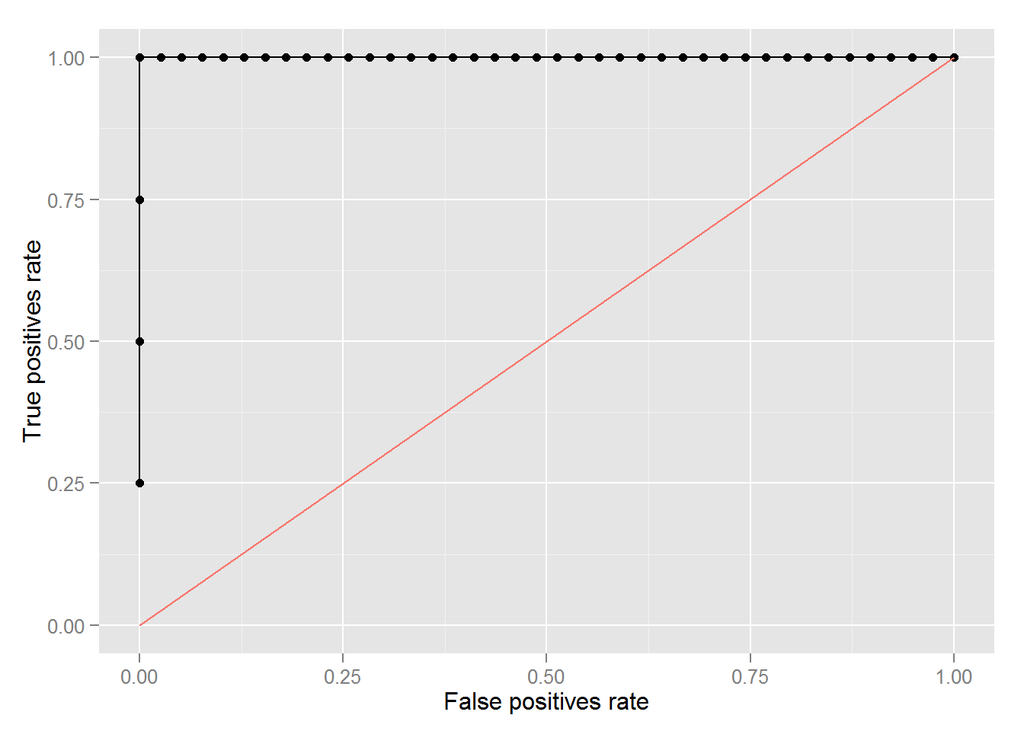

**Manhattan Plot**

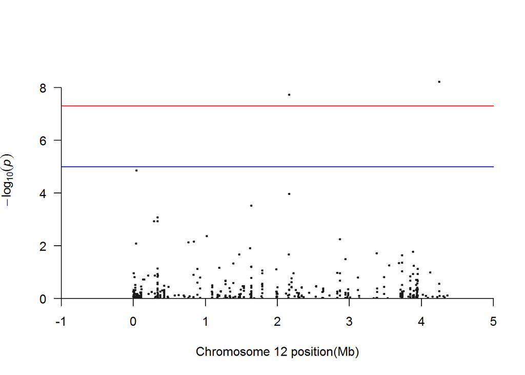

```r
manhattan(test.gwas, cex = .5)
```

**Q-Q Plot**

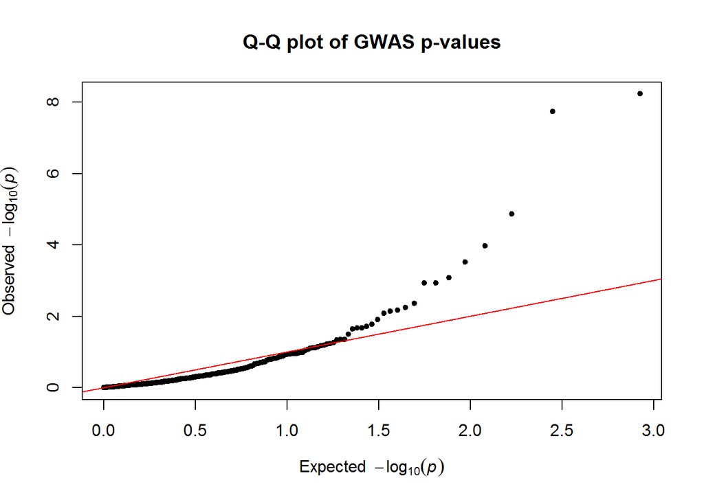

**Significant mutations**

|  | ps | allele1 | allele0 | af | p_lrt | bonferroni | holm | hochberg | fdr | BY |
| --- | --- | --- | --- | --- | --- | --- | --- | --- | --- | --- |
| 32 | 35978 | A | G | 0.070 | 0.008256205000 | 1.000000000 | 1.000000000 | 0.999953300 | 0.268009116 | 1.00000000 |
| 35 | 42227 | A | G | 0.047 | 0.000013686210 | 0.005775581 | 0.005748208 | 0.005748208 | 0.001925194 | 0.01275134 |
| 74 | 285751 | T | C | 0.116 | 0.001174536000 | 0.495654192 | 0.487432440 | 0.487432440 | 0.061956774 | 0.41036483 |
| 92 | 336344 | G | A | 0.023 | 0.000831722400 | 0.350986853 | 0.346828241 | 0.346828241 | 0.058497809 | 0.38745470 |
| 93 | 336369 | T | C | 0.047 | 0.001165652000 | 0.491905144 | 0.484911232 | 0.484911232 | 0.061956774 | 0.41036483 |
| 134 | 761158 | T | C | 0.419 | 0.007283371000 | 1.000000000 | 1.000000000 | 0.999953300 | 0.256131880 | 1.00000000 |
| 139 | 837914 | G | T | 0.070 | 0.006796641000 | 1.000000000 | 1.000000000 | 0.999953300 | 0.256131880 | 1.00000000 |
| 146 | 1020196 | C | T | 0.093 | 0.004348403000 | 1.000000000 | 1.000000000 | 0.999953300 | 0.203891785 | 1.00000000 |
| 221 | 1637662 | C | G | 0.070 | 0.000302934000 | 0.127838148 | 0.126626412 | 0.126626412 | 0.025567630 | 0.16934477 |
| 255 | 2163353 | A | C | 0.047 | 0.000000018068 | 0.000007625 | 0.000007607 | 0.000007607 | 0.000003812 | 0.00002525 |
| 256 | 2163357 | T | C | 0.023 | 0.000105360600 | 0.044462173 | 0.044146091 | 0.044146091 | 0.011115543 | 0.07362275 |
| 303 | 2867453 | C | T | 0.209 | 0.005692868000 | 1.000000000 | 1.000000000 | 0.999953300 | 0.240239030 | 1.00000000 |
| 416 | 4247607 | G | A | 0.140 | 0.000000005913 | 0.000002495 | 0.000002495 | 0.000002495 | 0.000002495 | 0.00001653 |

## ‘ETH’ Details

**ROC learning curve**

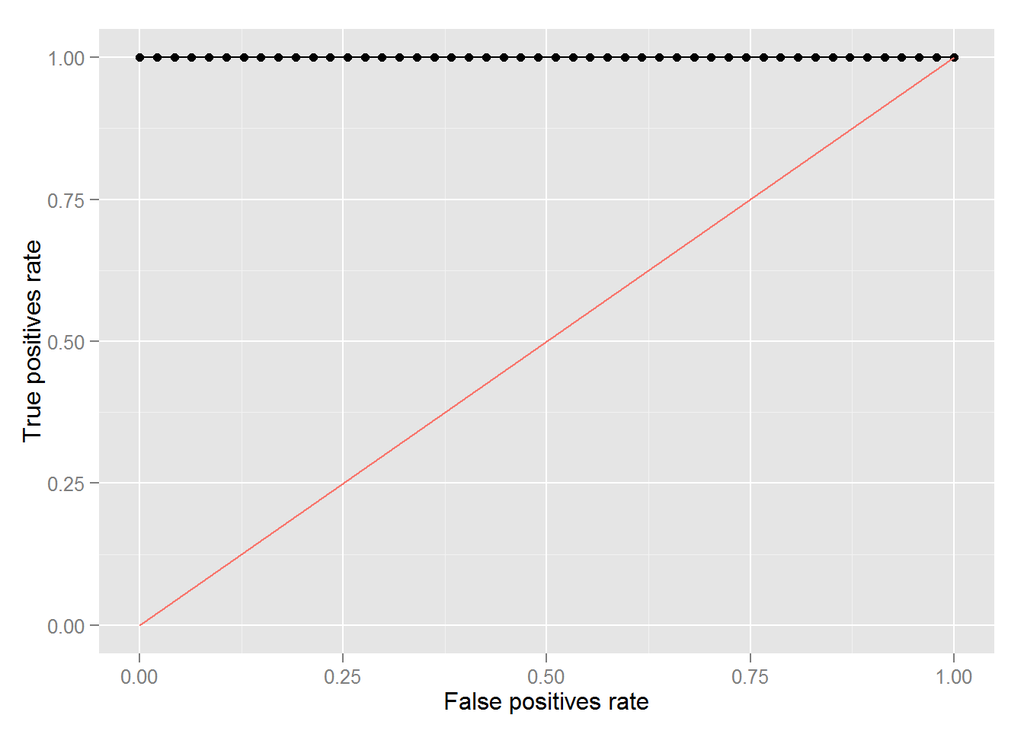

**Manhattan Plot**

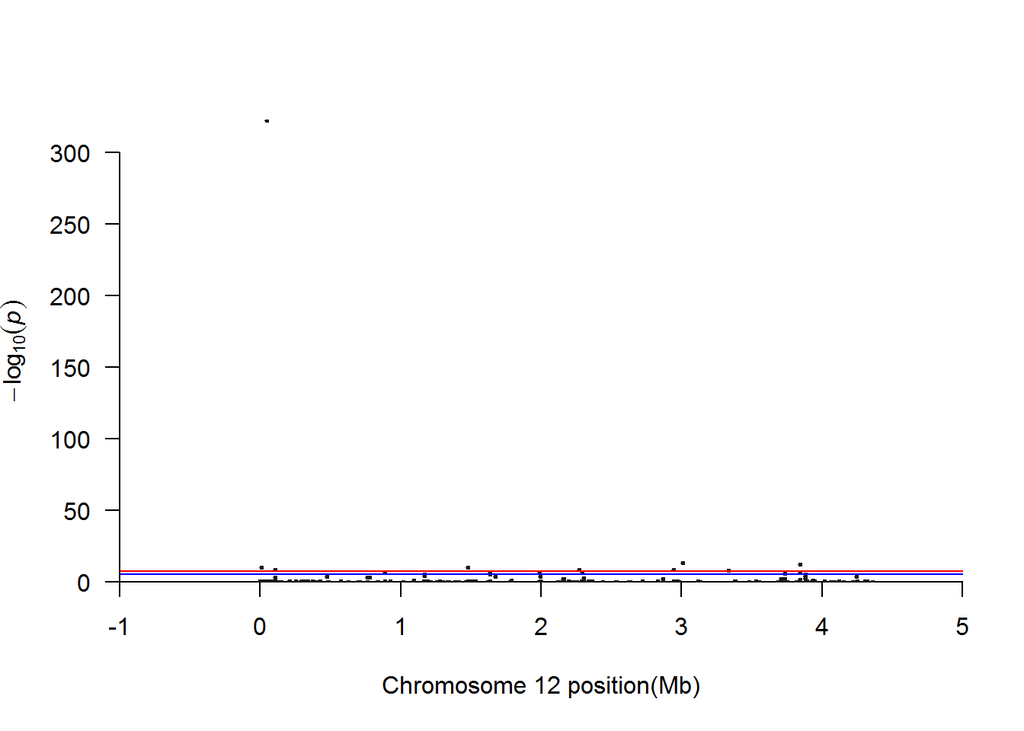

```r
manhattan(test.gwas, cex = .5)
```

**Q-Q Plot**

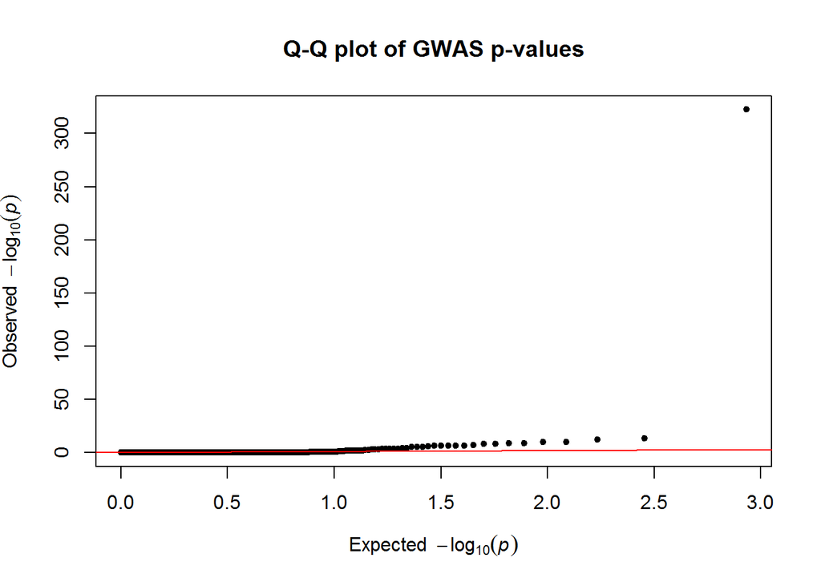

**Significant mutations**

|  | ps | allele1 | allele0 | af | p_lrt | bonferroni | holm | hochberg | fdr | BY |
| --- | --- | --- | --- | --- | --- | --- | --- | --- | --- | --- |
| 21 | 10878 | T | C | 0.021 | 0.00000000007837745 | 0.00000003354555 | 0.00000003323204 | 0.00000003323204 | 0.00000000670911 | 0.00000004453176 |
| 92 | 46053 | G | A | 0.021 | 0.00000000000000000 | 0.00000000000000 | 0.00000000000000 | 0.00000000000000 | 0.00000000000000 | 0.00000000000000 |
| 207 | 105004 | C | G | 0.458 | 0.00072672830000000 | 0.31103971240000 | 0.29141804830000 | 0.29141804830000 | 0.01110856115714 | 0.07373314832881 |
| 208 | 105008 | G | A | 0.438 | 0.00000000253013700 | 0.00000108289864 | 0.00000107024795 | 0.00000107024795 | 0.00000018048311 | 0.00000119795781 |
| 745 | 475181 | T | C | 0.083 | 0.00029937450000000 | 0.12813228600000 | 0.12124667250000 | 0.12124667250000 | 0.00533884525000 | 0.03543662074271 |
| 1034 | 761158 | T | C | 0.396 | 0.00111552400000000 | 0.47744427200000 | 0.44620960000000 | 0.44620960000000 | 0.01646359558621 | 0.10927722485489 |
| 1066 | 781690 | G | A | 0.333 | 0.00055301250000000 | 0.23668935000000 | 0.22231102500000 | 0.22231102500000 | 0.00876627222222 | 0.05818618999422 |
| 1199 | 891014 | A | G | 0.229 | 0.00000029465230000 | 0.00012611118440 | 0.00012257535680 | 0.00012257535680 | 0.00000970086034 | 0.00006438952481 |
| 1546 | 1169452 | A | G | 0.083 | 0.00006063006000000 | 0.02594966568000 | 0.02479769454000 | 0.02479769454000 | 0.00129748328400 | 0.00861205389969 |
| 1547 | 1169970 | A | G | 0.083 | 0.00000838146400000 | 0.00358726659200 | 0.00344478170400 | 0.00344478170400 | 0.00019929258844 | 0.00132280587708 |
| 1924 | 1481191 | C | A | 0.188 | 0.00000000007165081 | 0.00000003066655 | 0.00000003045159 | 0.00000003045159 | 0.00000000670911 | 0.00000004453176 |
| 2147 | 1638194 | T | C | 0.062 | 0.00000055205820000 | 0.00023628090960 | 0.00022855209480 | 0.00022855209480 | 0.00001575206064 | 0.00010455440693 |
| 2149 | 1638200 | C | G | 0.042 | 0.00000789425800000 | 0.00337874242400 | 0.00325243429600 | 0.00325243429600 | 0.00019874955435 | 0.00131920148470 |
| 2183 | 1673431 | T | C | 0.104 | 0.00031981630000000 | 0.13688137640000 | 0.12920578520000 | 0.12920578520000 | 0.00547525505600 | 0.03634204173441 |
| 2544 | 1989061 | A | T | 0.083 | 0.00000027402920000 | 0.00011728449760 | 0.00011427017640 | 0.00011427017640 | 0.00000970086034 | 0.00006438952481 |
| 2545 | 1989064 | G | A | 0.104 | 0.00000012978550000 | 0.00005554819400 | 0.00005438012450 | 0.00005438012450 | 0.00000555481940 | 0.00003687015060 |
| 2554 | 1996403 | T | A | 0.062 | 0.00045384770000000 | 0.19424681560000 | 0.18290062310000 | 0.18290062310000 | 0.00747103136923 | 0.04958902024521 |
| 2991 | 2269788 | T | C | 0.042 | 0.00000000319633400 | 0.00000136803095 | 0.00000134885295 | 0.00000134885295 | 0.00000019543299 | 0.00000129718779 |
| 3024 | 2296189 | A | G | 0.333 | 0.00000022573030000 | 0.00009661256840 | 0.00009435526540 | 0.00009435526540 | 0.00000878296076 | 0.00005829696030 |
| 3042 | 2301790 | C | T | 0.083 | 0.00593657700000000 | 1.00000000000000 | 1.00000000000000 | 0.99994920000000 | 0.08196306309677 | 0.54403037470902 |
| 3803 | 2867766 | T | C | 0.479 | 0.00906121500000000 | 1.00000000000000 | 1.00000000000000 | 0.99994920000000 | 0.12119375062500 | 0.80442432327184 |
| 3882 | 2944867 | G | T | 0.042 | 0.00000000384211500 | 0.00000164442522 | 0.00000161753042 | 0.00000161753042 | 0.00000020555315 | 0.00000136436041 |
| 3966 | 3007156 | C | G | 0.083 | 0.00000000000006742 | 0.00000000002885 | 0.00000000002879 | 0.00000000002879 | 0.00000000001443 | 0.00000000009576 |
| 4280 | 3336597 | A | T | 0.146 | 0.00000001394154000 | 0.00000596697912 | 0.00000585544680 | 0.00000585544680 | 0.00000066299768 | 0.00000440065150 |
| 4724 | 3736432 | G | A | 0.042 | 0.00000191905100000 | 0.00082135382800 | 0.00079256806300 | 0.00079256806300 | 0.00005133461425 | 0.00034073384243 |
| 4951 | 3842746 | A | G | 0.062 | 0.00000045416050000 | 0.00019438069400 | 0.00018847660750 | 0.00018847660750 | 0.00001388433529 | 0.00009215736751 |
| 4952 | 3842747 | A | C | 0.083 | 0.00000000000064051 | 0.00000000027414 | 0.00000000027286 | 0.00000000027286 | 0.00000000009138 | 0.00000000060653 |
| 5021 | 3883976 | G | A | 0.292 | 0.00007726621000000 | 0.03306993788000 | 0.03152461368000 | 0.03152461368000 | 0.00157475894667 | 0.01045247294894 |
| 5023 | 3884024 | C | T | 0.104 | 0.00344539500000000 | 1.00000000000000 | 1.00000000000000 | 0.99994920000000 | 0.04915430200000 | 0.32626200541147 |
| 5027 | 3884094 | A | G | 0.083 | 0.00025228810000000 | 0.10797930680000 | 0.10242896860000 | 0.10242896860000 | 0.00469475246957 | 0.03116145064232 |
| 5028 | 3884523 | G | C | 0.042 | 0.00000900621100000 | 0.00385465830800 | 0.00369254651000 | 0.00369254651000 | 0.00020287675305 | 0.00134659579343 |
| 5555 | 4247607 | G | A | 0.125 | 0.00019568970000000 | 0.08375519160000 | 0.07964570790000 | 0.07964570790000 | 0.00380705416364 | 0.02526934725140 |

## ‘ETH-nodup’ Details

**ROC learning curve**

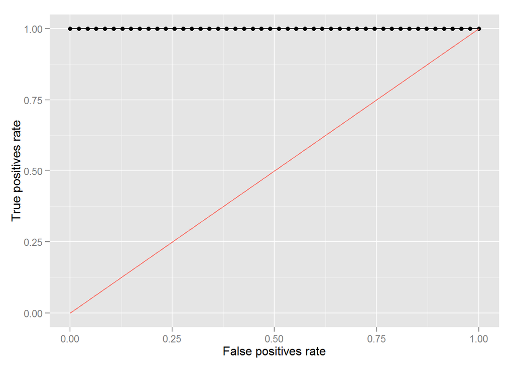

**Manhattan Plot**

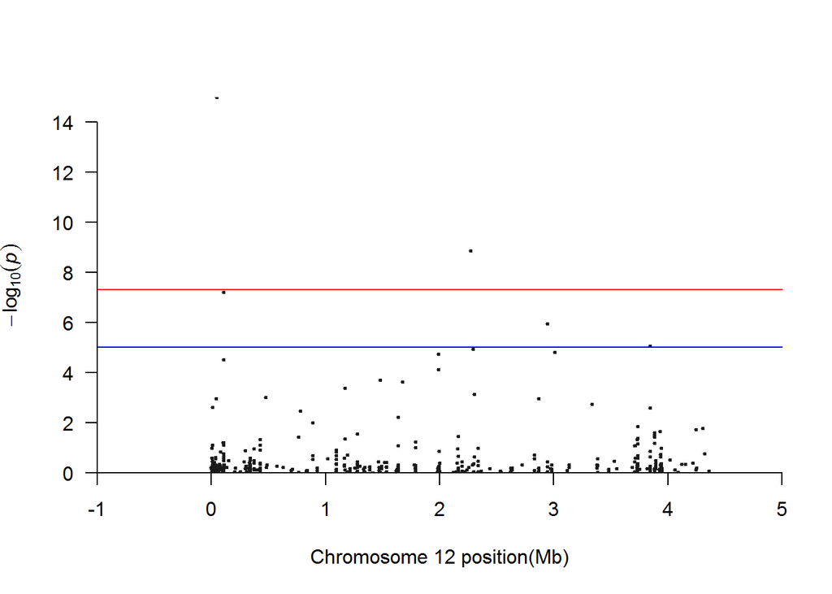

```r
manhattan(test.gwas, cex = .5)
```

**Q-Q Plot**

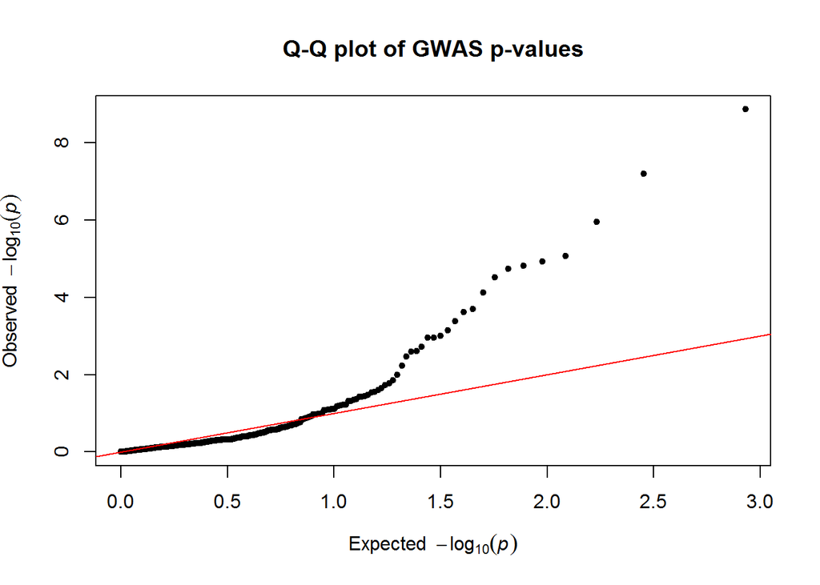

**Significant mutations**

|  | ps | allele1 | allele0 | af | p_lrt | bonferroni | holm | hochberg | fdr | BY |
| --- | --- | --- | --- | --- | --- | --- | --- | --- | --- | --- |
| 17 | 10878 | T | C | 0.021 | 0.002458859000 | 1.0000000000 | 1.0000000000 | 0.9993077000 | 0.0541343602 | 0.359317175 |
| 38 | 40237 | A | G | 0.042 | 0.001106769000 | 0.4736971320 | 0.4570955970 | 0.4570955970 | 0.0283750656 | 0.188339686 |
| 40 | 46053 | G | A | 0.021 | 0.000000000000 | 0.0000000000 | 0.0000000000 | 0.0000000000 | 0.0000000000 | 0.000000000 |
| 69 | 105004 | C | G | 0.458 | 0.000029852740 | 0.0127769727 | 0.0125381508 | 0.0125381508 | 0.0014196636 | 0.009423027 |
| 70 | 105008 | G | A | 0.438 | 0.000000061722 | 0.0000264171 | 0.0000262936 | 0.0000262936 | 0.0000088057 | 0.000058448 |
| 132 | 475181 | T | C | 0.083 | 0.001008074000 | 0.4314556720 | 0.4173426360 | 0.4173426360 | 0.0283750656 | 0.188339686 |
| 141 | 781690 | G | A | 0.333 | 0.003411689000 | 1.0000000000 | 1.0000000000 | 0.9993077000 | 0.0695334710 | 0.461528875 |
| 168 | 1169970 | A | G | 0.083 | 0.000418991300 | 0.1793282764 | 0.1743003808 | 0.1743003808 | 0.0137944828 | 0.091560971 |
| 199 | 1481191 | C | A | 0.188 | 0.000201269600 | 0.0861433888 | 0.0841306928 | 0.0841306928 | 0.0078312172 | 0.051979756 |
| 229 | 1638194 | T | C | 0.062 | 0.005975523000 | 1.0000000000 | 1.0000000000 | 0.9993077000 | 0.1162510838 | 0.771617340 |
| 231 | 1673431 | T | C | 0.104 | 0.000240658900 | 0.1030020092 | 0.1003547613 | 0.1003547613 | 0.0085835008 | 0.056973043 |
| 249 | 1989061 | A | T | 0.083 | 0.000018555960 | 0.0079419509 | 0.0078120592 | 0.0078120592 | 0.0009927439 | 0.006589344 |
| 250 | 1989064 | G | A | 0.104 | 0.000075934350 | 0.0324999018 | 0.0318164927 | 0.0318164927 | 0.0032499902 | 0.021571831 |
| 274 | 2269788 | T | C | 0.042 | 0.000000001353 | 0.0000005791 | 0.0000005777 | 0.0000005777 | 0.0000002895 | 0.000001922 |
| 277 | 2296189 | A | G | 0.333 | 0.000011804890 | 0.0050524929 | 0.0049934685 | 0.0049934685 | 0.0008420822 | 0.005589326 |
| 280 | 2301790 | C | T | 0.083 | 0.000723606500 | 0.3097035820 | 0.3002966975 | 0.3002966975 | 0.0221216844 | 0.146832827 |
| 310 | 2867766 | T | C | 0.479 | 0.001127047000 | 0.4823761160 | 0.4643433640 | 0.4643433640 | 0.0283750656 | 0.188339686 |
| 314 | 2944867 | G | T | 0.042 | 0.000001090933 | 0.0004669193 | 0.0004636465 | 0.0004636465 | 0.0001167298 | 0.000774795 |
| 319 | 3007156 | C | G | 0.083 | 0.000015233340 | 0.0065198695 | 0.0064284695 | 0.0064284695 | 0.0009314099 | 0.006182240 |
| 324 | 3336597 | A | T | 0.146 | 0.001888923000 | 0.8084590440 | 0.7763473530 | 0.7763473530 | 0.0449143913 | 0.298119570 |
| 363 | 3842746 | A | G | 0.062 | 0.002529643000 | 1.0000000000 | 1.0000000000 | 0.9993077000 | 0.0541343602 | 0.359317175 |
| 364 | 3842747 | A | C | 0.083 | 0.000008648038 | 0.0037013603 | 0.0036667681 | 0.0036667681 | 0.0007402721 | 0.004913561 |

## ‘PARA’ Details

**ROC learning curve**

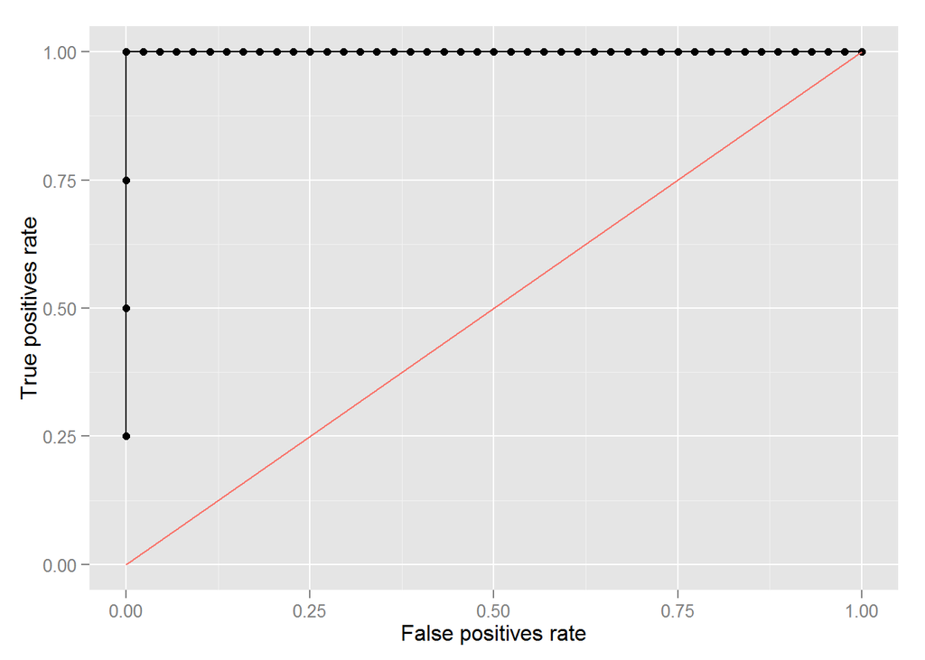

**Manhattan Plot**

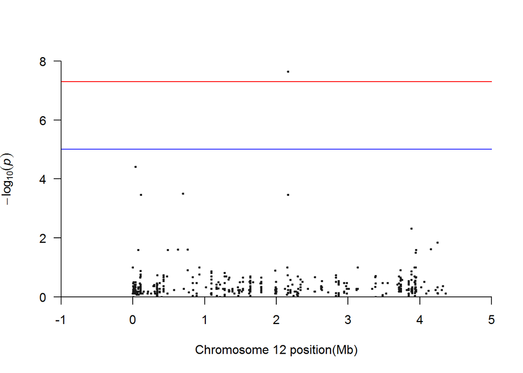

```r
manhattan(test.gwas, cex = .5)
```

**Q-Q Plot**

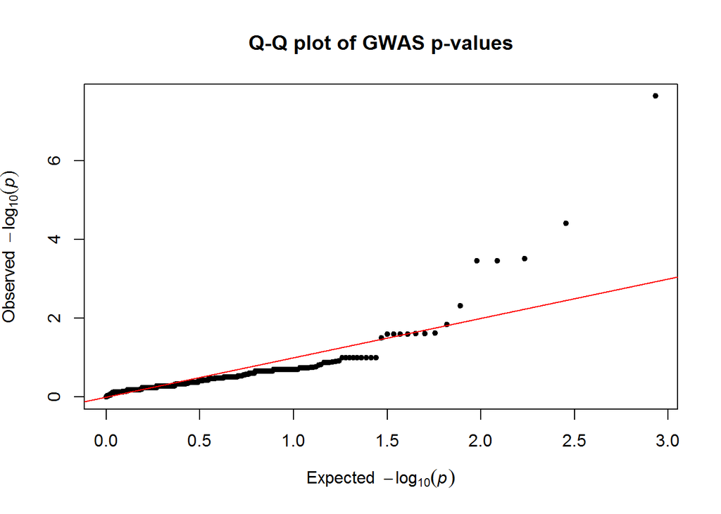

**Significant mutations**

|  | ps | allele1 | allele0 | af | p_lrt | bonferroni | holm | hochberg | fdr | BY |
| --- | --- | --- | --- | --- | --- | --- | --- | --- | --- | --- |
| 74 | 35978 | A | G | 0.062 | 0.00003913272 | 0.016748804 | 0.016709671 | 0.016709671 | 0.008374402 | 0.05558515 |
| 221 | 115154 | G | A | 0.021 | 0.00034695950 | 0.148498666 | 0.147457787 | 0.147113457 | 0.029700264 | 0.19713570 |
| 970 | 699720 | C | A | 0.021 | 0.00031234880 | 0.133685286 | 0.133060589 | 0.133060589 | 0.029700264 | 0.19713570 |
| 2780 | 2163353 | A | C | 0.042 | 0.00000002294 | 0.000009819 | 0.000009819 | 0.000009819 | 0.000009819 | 0.00006517 |
| 2782 | 2163357 | T | C | 0.021 | 0.00034696570 | 0.148501320 | 0.147457787 | 0.147113457 | 0.029700264 | 0.19713570 |
| 5023 | 3884024 | C | T | 0.104 | 0.00480778700 | 1.000000000 | 1.000000000 | 0.999976200 | 0.342955473 | 1.00000000 |

## ‘PARA-nodup’ Details

**ROC learning curve**

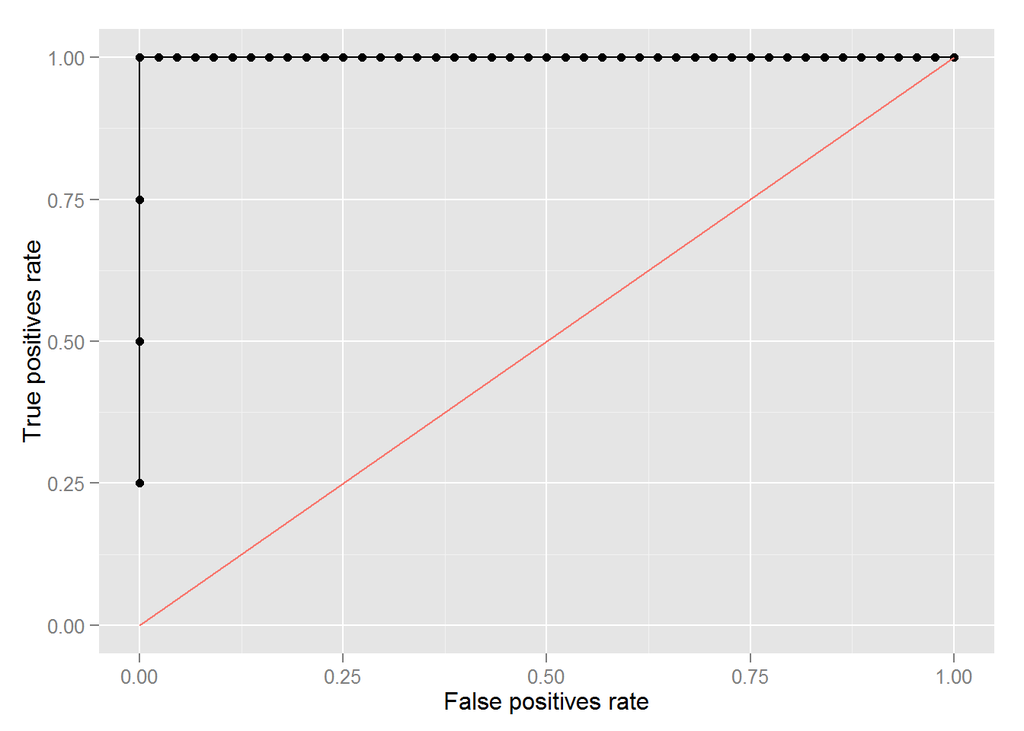

**Manhattan Plot**

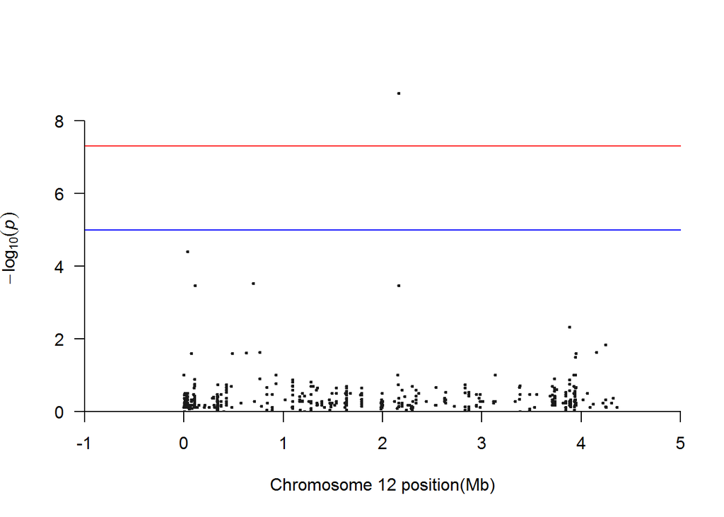

```r
manhattan(test.gwas, cex = .5)
```

**Q-Q Plot**

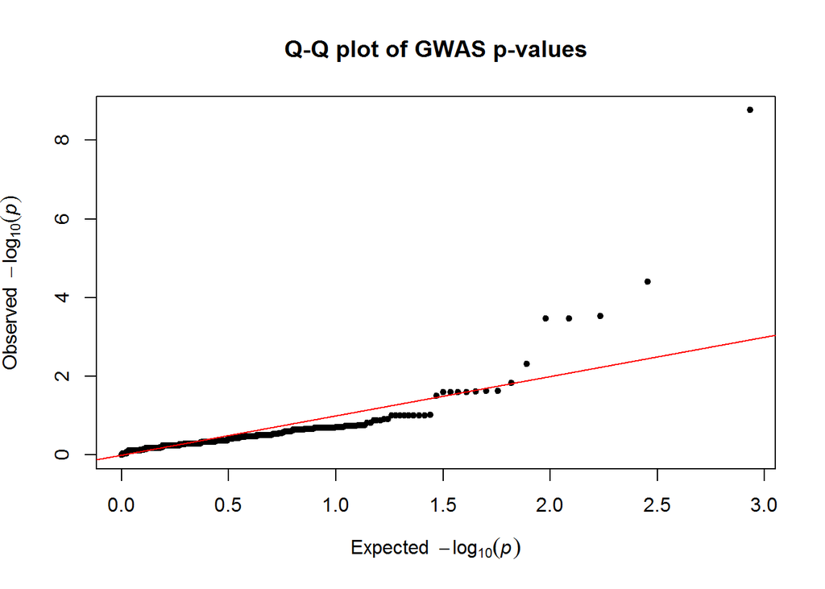

**Significant mutations**

|  | ps | allele1 | allele0 | af | p_lrt | bonferroni | holm | hochberg | fdr | BY |
| --- | --- | --- | --- | --- | --- | --- | --- | --- | --- | --- |
| 36 | 35978 | A | G | 0.062 | 0.000039132490 | 0.0167487057 | 0.0167095732 | 0.0167095732 | 0.0083743529 | 0.05558482 |
| 73 | 115154 | G | A | 0.021 | 0.000346961600 | 0.1484995648 | 0.1474586800 | 0.1471131600 | 0.0297002040 | 0.19713530 |
| 137 | 699720 | C | A | 0.021 | 0.000294893500 | 0.1262144180 | 0.1256246310 | 0.1256246310 | 0.0297002040 | 0.19713530 |
| 261 | 2163353 | A | C | 0.042 | 0.000000001718 | 0.0000007352 | 0.0000007352 | 0.0000007352 | 0.0000007352 | 0.00000488 |
| 262 | 2163357 | T | C | 0.021 | 0.000346965000 | 0.1485010200 | 0.1474586800 | 0.1471131600 | 0.0297002040 | 0.19713530 |
| 374 | 3884024 | C | T | 0.104 | 0.004807769000 | 1.0000000000 | 1.0000000000 | 0.9999747000 | 0.3429541887 | 1.00000000 |

# Dataset: ‘dataset_9-2ndLineNonInj_bin’ prediction accuracy summary

| drug | 1 | 0 | 1/1 | 1/0 | 0/1 | 0/0 | precission | recall | f1 | accuracy |
| --- | --- | --- | --- | --- | --- | --- | --- | --- | --- | --- |
| CYCL | 46 | 70 | 0.3966 | 0.0000 | 0.6034 | 0.0000 | 0.3966 | 1.0000 | 0.5679 | 0.3966 |
| CYCL-nodup | 46 | 70 | 0.3966 | 0.0000 | 0.6034 | 0.0000 | 0.3966 | 1.0000 | 0.5679 | 0.3966 |
| ETH | 33 | 89 | 0.2377 | 0.0328 | 0.1803 | 0.5492 | 0.5686 | 0.8788 | 0.6905 | 0.7869 |
| ETH-nodup | 33 | 89 | 0.2705 | 0.0000 | 0.6311 | 0.0984 | 0.3000 | 1.0000 | 0.4615 | 0.3689 |
| PARA | 22 | 100 | 0.1639 | 0.0164 | 0.0902 | 0.7295 | 0.6452 | 0.9091 | 0.7547 | 0.8934 |
| PARA-nodup | 22 | 100 | 0.1148 | 0.0656 | 0.0656 | 0.7541 | 0.6364 | 0.6364 | 0.6364 | 0.8689 |

## ‘CYCL’ Details

**ROC learning curve**

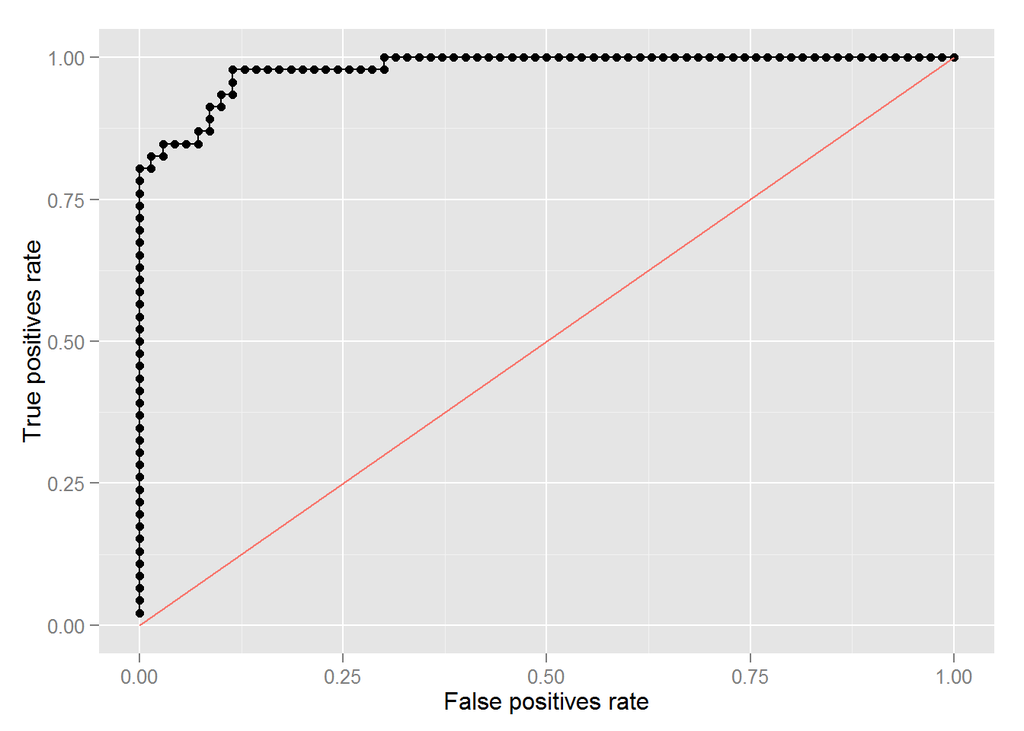

**Manhattan Plot**

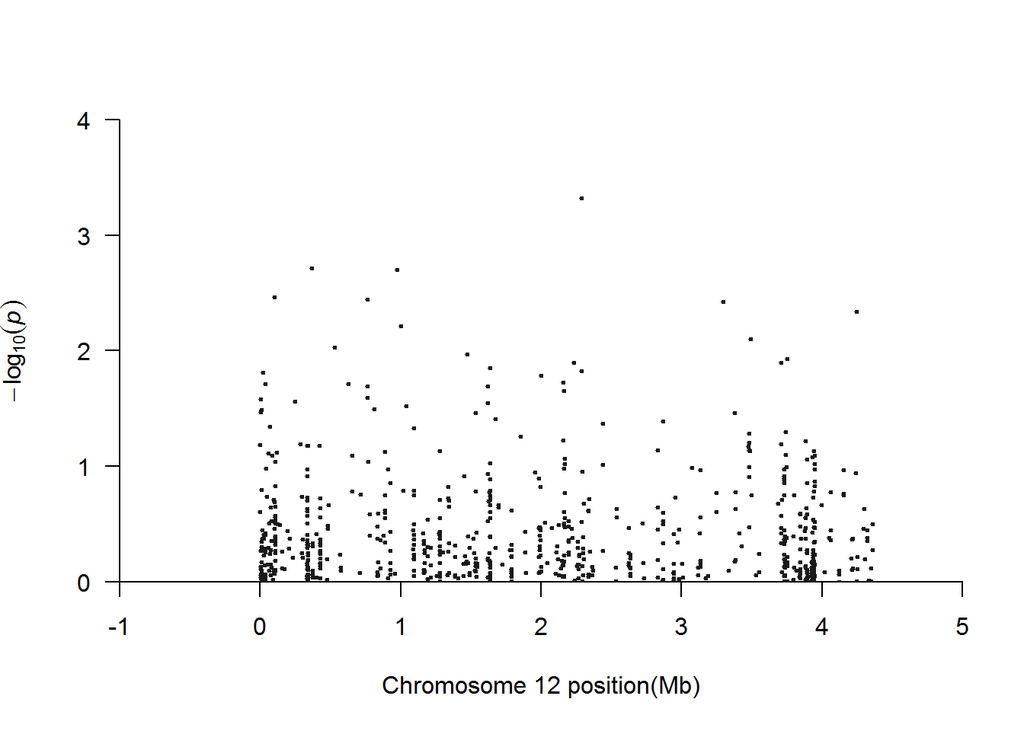

```r
manhattan(test.gwas, cex = .5)
```

**Q-Q Plot**

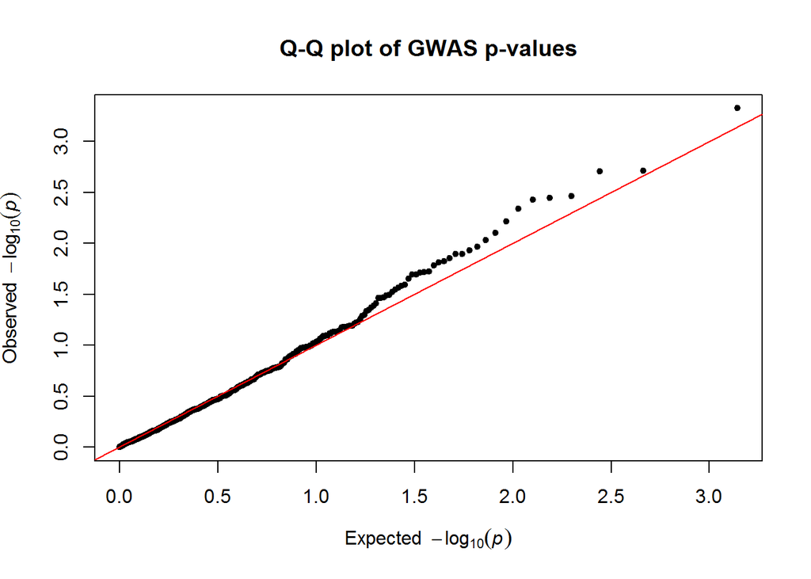

**Significant mutations**

|  | ps | allele1 | allele0 | af | p_lrt | bonferroni | holm | hochberg | fdr | BY |
| --- | --- | --- | --- | --- | --- | --- | --- | --- | --- | --- |
| 139 | 103599 | G | C | 0.129 | 0.003447 | 1.0000 | 1.0000 | 0.9984 | 0.4328 | 1 |
| 440 | 365328 | C | T | 0.172 | 0.001939 | 1.0000 | 1.0000 | 0.9984 | 0.4328 | 1 |
| 590 | 528976 | T | C | 0.017 | 0.009360 | 1.0000 | 1.0000 | 0.9984 | 0.6109 | 1 |
| 754 | 764825 | T | G | 0.078 | 0.003613 | 1.0000 | 1.0000 | 0.9984 | 0.4328 | 1 |
| 961 | 973064 | C | G | 0.138 | 0.001984 | 1.0000 | 1.0000 | 0.9984 | 0.4328 | 1 |
| 973 | 1001128 | T | C | 0.172 | 0.006131 | 1.0000 | 1.0000 | 0.9984 | 0.5318 | 1 |
| 2195 | 2289048 | C | A | 0.190 | 0.000475 | 0.3296 | 0.3296 | 0.3296 | 0.3296 | 1 |
| 3072 | 3294907 | A | G | 0.164 | 0.003742 | 1.0000 | 1.0000 | 0.9984 | 0.4328 | 1 |
| 3206 | 3491581 | C | G | 0.147 | 0.007872 | 1.0000 | 1.0000 | 0.9984 | 0.6070 | 1 |
| 3968 | 4247607 | G | A | 0.112 | 0.004568 | 1.0000 | 1.0000 | 0.9984 | 0.4529 | 1 |

## ‘CYCL-nodup’ Details

**ROC learning curve**

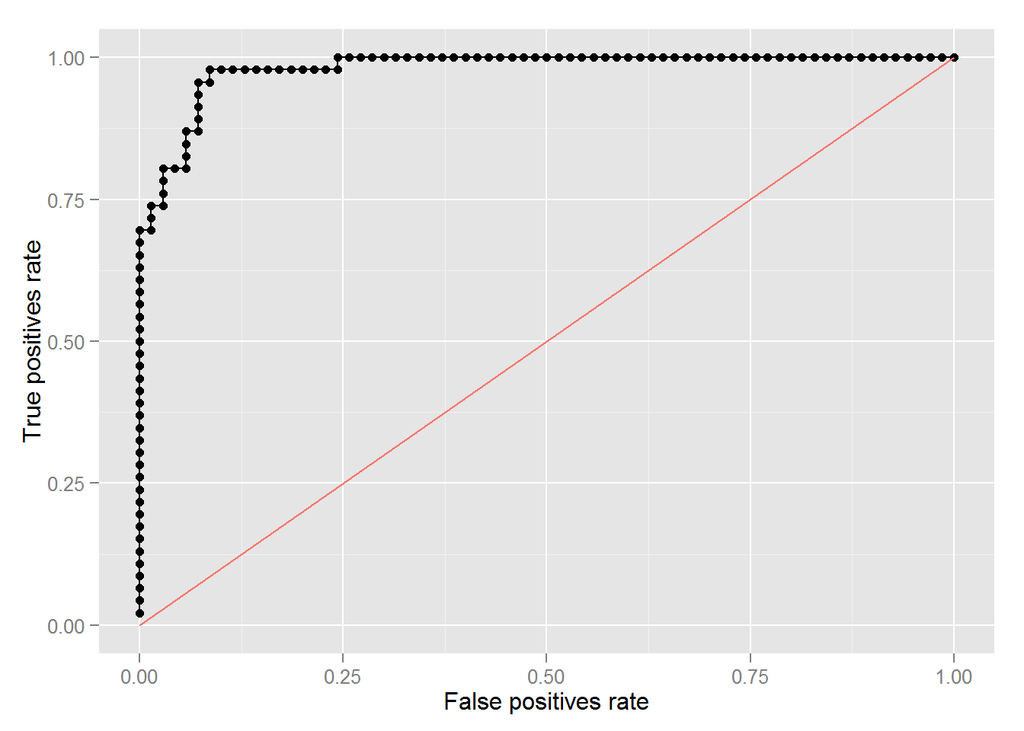

**Manhattan Plot**

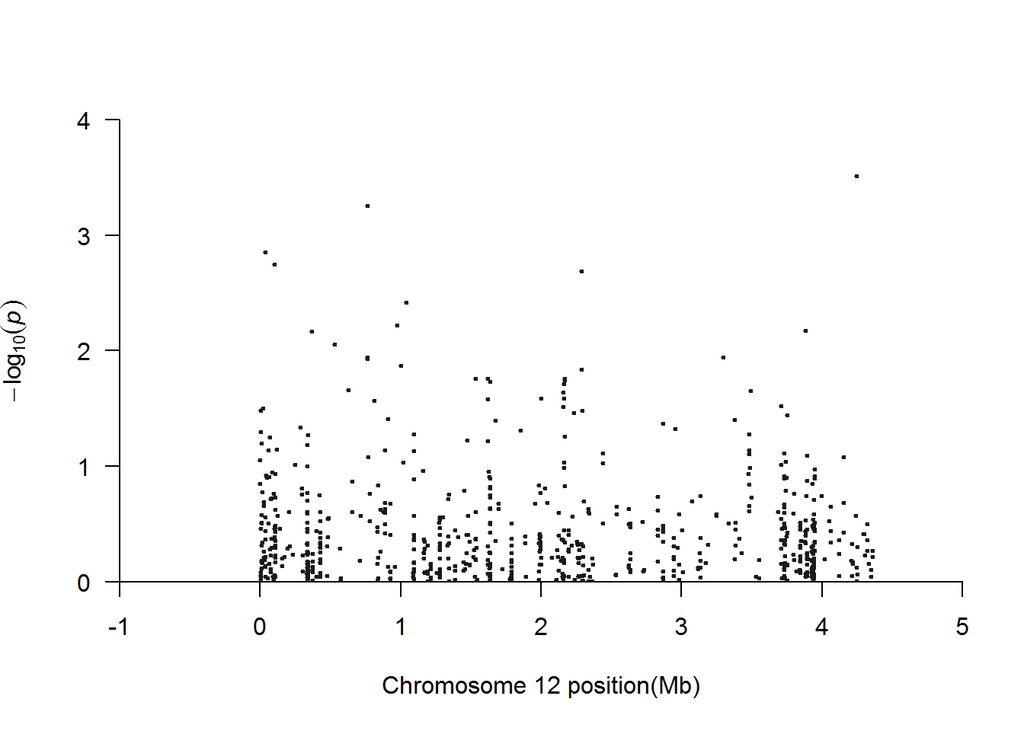

```r
manhattan(test.gwas, cex = .5)
```

**Q-Q Plot**

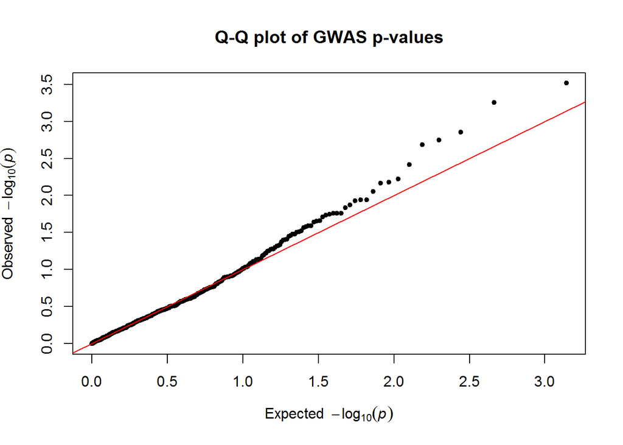

**Significant mutations**

|  | ps | allele1 | allele0 | af | p_lrt | bonferroni | holm | hochberg | fdr | BY |
| --- | --- | --- | --- | --- | --- | --- | --- | --- | --- | --- |
| 31 | 35978 | A | G | 0.086 | 0.0014012 | 0.9724 | 0.9696 | 0.9696 | 0.2860 | 1 |
| 56 | 103599 | G | C | 0.129 | 0.0017830 | 1.0000 | 1.0000 | 0.9975 | 0.2860 | 1 |
| 132 | 365328 | C | T | 0.172 | 0.0068576 | 1.0000 | 1.0000 | 0.9975 | 0.5288 | 1 |
| 164 | 528976 | T | C | 0.017 | 0.0088166 | 1.0000 | 1.0000 | 0.9975 | 0.6119 | 1 |
| 175 | 764825 | T | G | 0.078 | 0.0005588 | 0.3878 | 0.3872 | 0.3872 | 0.1939 | 1 |
| 205 | 973064 | C | G | 0.138 | 0.0059973 | 1.0000 | 1.0000 | 0.9975 | 0.5288 | 1 |
| 208 | 1040013 | C | T | 0.060 | 0.0038404 | 1.0000 | 1.0000 | 0.9975 | 0.4442 | 1 |
| 428 | 2289048 | C | A | 0.190 | 0.0020605 | 1.0000 | 1.0000 | 0.9975 | 0.2860 | 1 |
| 595 | 3884024 | C | T | 0.095 | 0.0066748 | 1.0000 | 1.0000 | 0.9975 | 0.5288 | 1 |
| 679 | 4247607 | G | A | 0.112 | 0.0003059 | 0.2123 | 0.2123 | 0.2123 | 0.1939 | 1 |

## ‘ETH’ Details

**ROC learning curve**

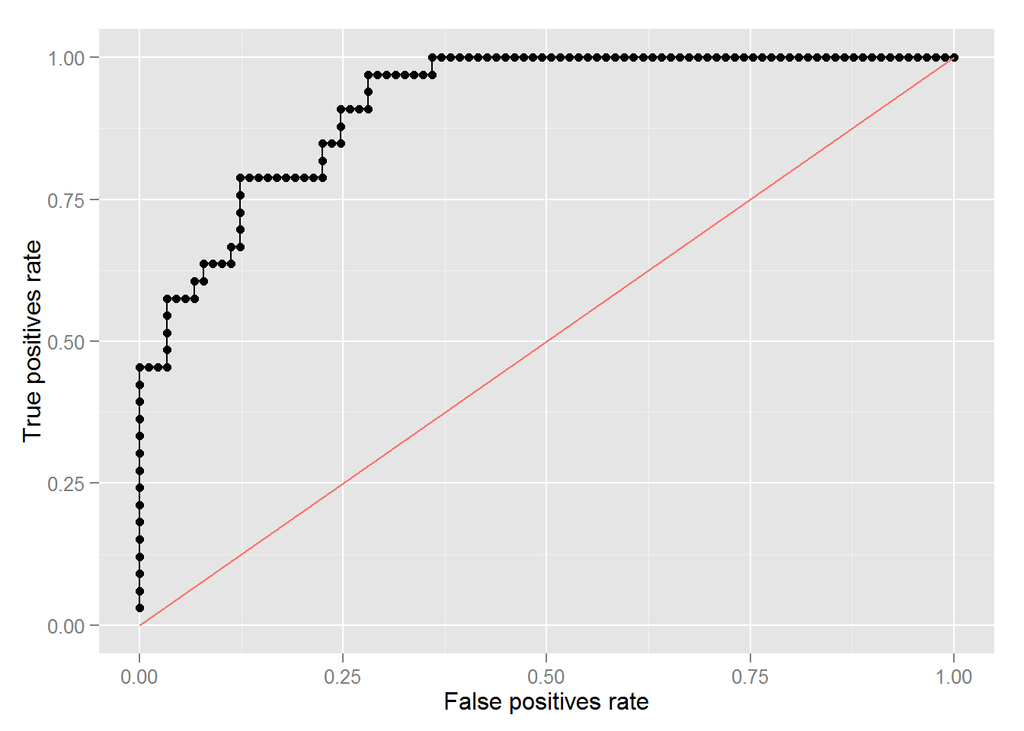

**Manhattan Plot**

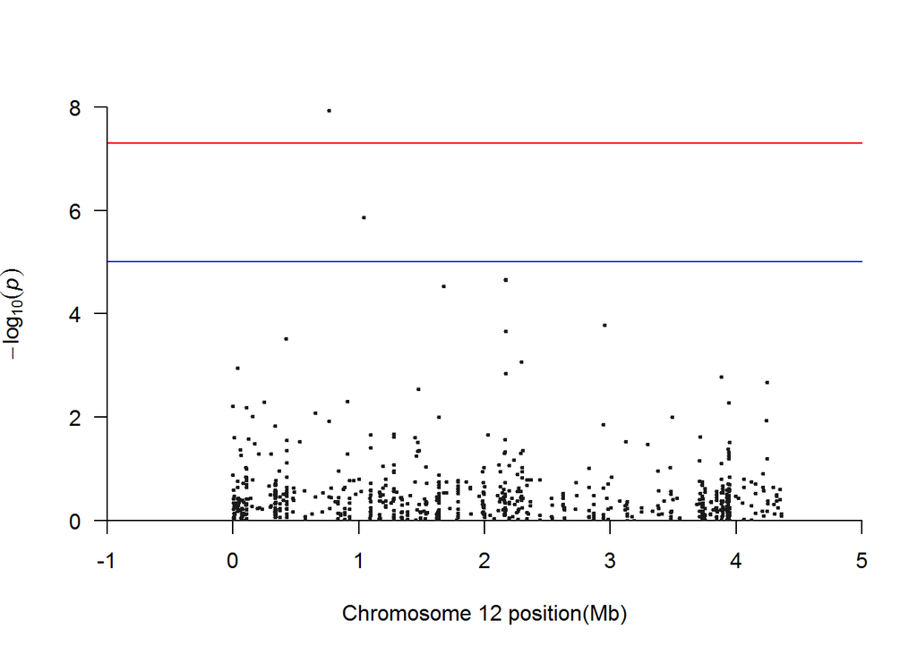

```r
manhattan(test.gwas, cex = .5)
```

**Q-Q Plot**

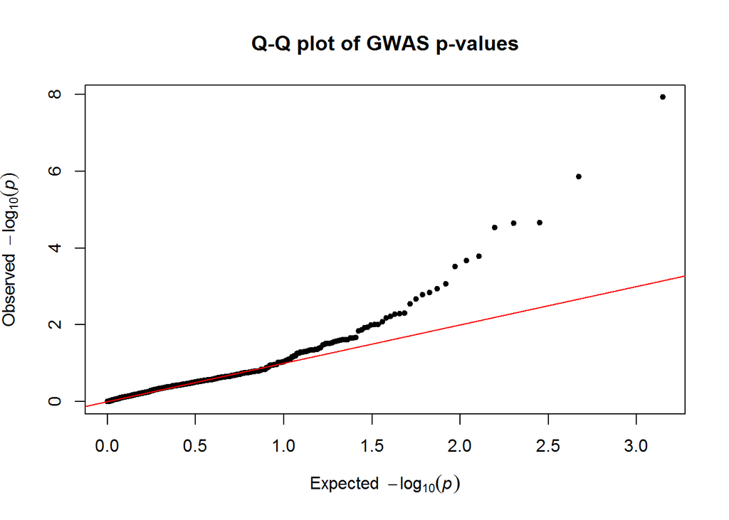

**Significant mutations**

|  | ps | allele1 | allele0 | af | p_lrt | bonferroni | holm | hochberg | fdr | BY |
| --- | --- | --- | --- | --- | --- | --- | --- | --- | --- | --- |
| 2 | 1288 | A | G | 0.016 | 0.00607039300 | 1.000000000 | 1.000000000 | 0.999216500 | 0.237757059 | 1.00000000 |
| 61 | 35978 | A | G | 0.082 | 0.00114134500 | 0.804648225 | 0.794376120 | 0.794376120 | 0.080464823 | 0.57420683 |
| 161 | 104912 | C | T | 0.057 | 0.00663164100 | 1.000000000 | 1.000000000 | 0.999216500 | 0.246068784 | 1.00000000 |
| 209 | 154281 | T | C | 0.016 | 0.00978304400 | 1.000000000 | 1.000000000 | 0.999216500 | 0.306997154 | 1.00000000 |
| 299 | 247551 | T | C | 0.033 | 0.00509690000 | 1.000000000 | 1.000000000 | 0.999216500 | 0.220225661 | 1.00000000 |
| 519 | 423970 | A | C | 0.025 | 0.00030555390 | 0.215415500 | 0.213276622 | 0.213276622 | 0.026926937 | 0.19215392 |
| 701 | 656166 | G | C | 0.016 | 0.00832984500 | 1.000000000 | 1.000000000 | 0.999216500 | 0.293627036 | 1.00000000 |
| 792 | 764825 | T | G | 0.074 | 0.00000001177 | 0.000008297 | 0.000008297 | 0.000008297 | 0.000008297 | 0.00005921 |
| 945 | 908189 | T | C | 0.377 | 0.00496918500 | 1.000000000 | 1.000000000 | 0.999216500 | 0.220225661 | 1.00000000 |
| 1056 | 1040013 | C | T | 0.057 | 0.00000138245 | 0.000974629 | 0.000973247 | 0.000973247 | 0.000487315 | 0.00347754 |
| 1466 | 1473252 | G | A | 0.393 | 0.00290060200 | 1.000000000 | 1.000000000 | 0.999216500 | 0.146066029 | 1.00000000 |
| 1623 | 1636179 | G | C | 0.115 | 0.00997342600 | 1.000000000 | 1.000000000 | 0.999216500 | 0.306997154 | 1.00000000 |
| 1673 | 1673431 | T | C | 0.213 | 0.00002932454 | 0.020673801 | 0.020556503 | 0.020556503 | 0.004134760 | 0.02950615 |
| 2167 | 2169051 | G | C | 0.041 | 0.00021580660 | 0.152143653 | 0.150848813 | 0.150848813 | 0.021734808 | 0.15510225 |
| 2168 | 2169054 | A | G | 0.033 | 0.00143929600 | 1.000000000 | 1.000000000 | 0.999216500 | 0.092245789 | 0.65827725 |
| 2171 | 2169070 | G | A | 0.049 | 0.00002164024 | 0.015256369 | 0.015213089 | 0.015213089 | 0.003927049 | 0.02802390 |
| 2172 | 2169072 | T | C | 0.049 | 0.00002228113 | 0.015708197 | 0.015641353 | 0.015641353 | 0.003927049 | 0.02802390 |
| 2335 | 2295693 | C | A | 0.443 | 0.00086503490 | 0.609849605 | 0.602929325 | 0.602929325 | 0.067761067 | 0.48355128 |
| 2989 | 2955148 | T | C | 0.041 | 0.00016525400 | 0.116504070 | 0.115677800 | 0.115677800 | 0.019417345 | 0.13856455 |
| 3794 | 3884024 | C | T | 0.098 | 0.00167098900 | 1.000000000 | 1.000000000 | 0.999216500 | 0.098170604 | 0.70055746 |
| 3919 | 3943903 | C | T | 0.016 | 0.00531040600 | 1.000000000 | 1.000000000 | 0.999216500 | 0.220225661 | 1.00000000 |
| 4203 | 4247607 | G | A | 0.107 | 0.00214302900 | 1.000000000 | 1.000000000 | 0.999216500 | 0.116218111 | 0.82934668 |

## ‘ETH-nodup’ Details

**ROC learning curve**

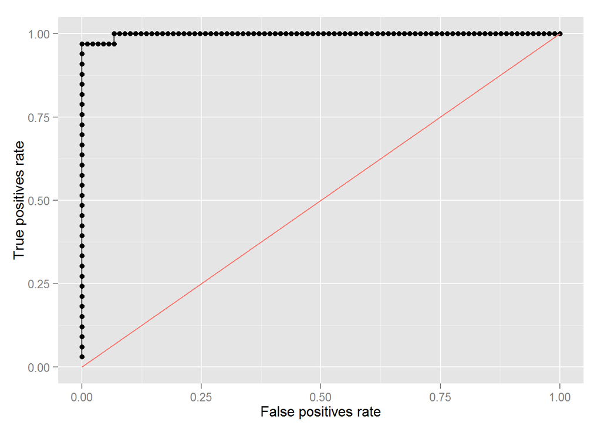

**Manhattan Plot**

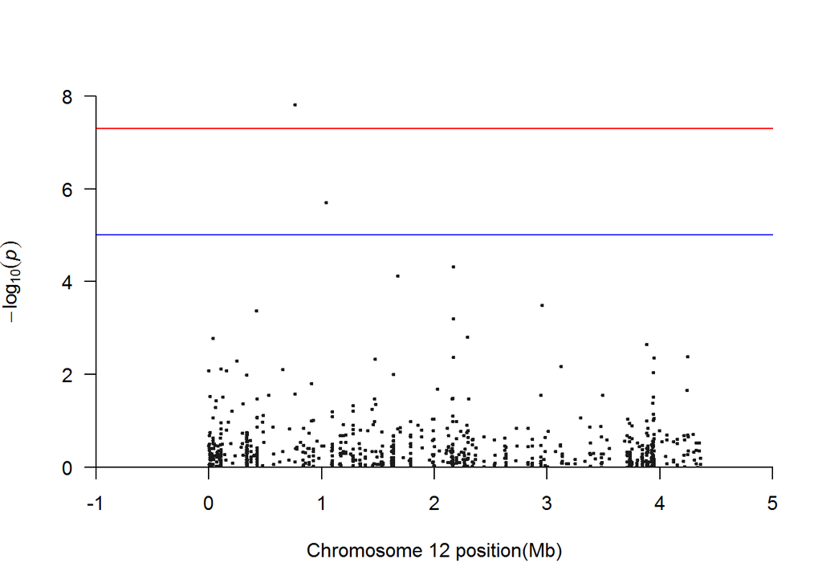

```r
manhattan(test.gwas, cex = .5)
```

**Q-Q Plot**

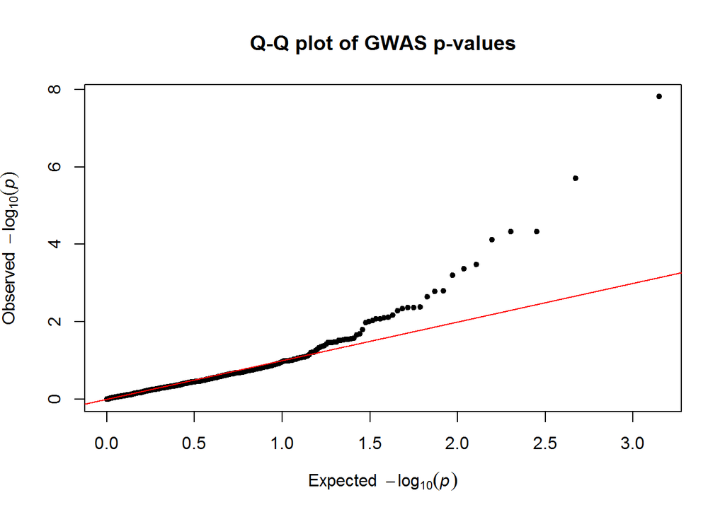

**Significant mutations**

|  | ps | allele1 | allele0 | af | p_lrt | bonferroni | holm | hochberg | fdr | BY |
| --- | --- | --- | --- | --- | --- | --- | --- | --- | --- | --- |
| 2 | 1288 | A | G | 0.016 | 0.00836371300 | 1.00000000 | 1.00000000 | 0.99852980 | 0.28093062 | 1.00000000 |
| 31 | 35978 | A | G | 0.082 | 0.00164497800 | 1.00000000 | 1.00000000 | 0.99852980 | 0.11597095 | 0.82758290 |
| 66 | 104912 | C | T | 0.057 | 0.00761298600 | 1.00000000 | 1.00000000 | 0.99852980 | 0.28093062 | 1.00000000 |
| 83 | 154281 | T | C | 0.016 | 0.00836814600 | 1.00000000 | 1.00000000 | 0.99852980 | 0.28093062 | 1.00000000 |
| 89 | 247551 | T | C | 0.033 | 0.00518547400 | 1.00000000 | 1.00000000 | 0.99852980 | 0.22848495 | 1.00000000 |
| 145 | 423970 | A | C | 0.025 | 0.00042385270 | 0.29881615 | 0.29627304 | 0.29627304 | 0.04268802 | 0.30462695 |
| 173 | 656166 | G | C | 0.016 | 0.00788581000 | 1.00000000 | 1.00000000 | 0.99852980 | 0.28093062 | 1.00000000 |
| 178 | 764825 | T | G | 0.074 | 0.00000001549 | 0.00001092 | 0.00001092 | 0.00001092 | 0.00001092 | 0.00007793 |
| 211 | 1040013 | C | T | 0.057 | 0.00000199135 | 0.00140390 | 0.00140191 | 0.00140191 | 0.00070195 | 0.00500921 |
| 285 | 1473252 | G | A | 0.393 | 0.00466327200 | 1.00000000 | 1.00000000 | 0.99852980 | 0.21917378 | 1.00000000 |
| 320 | 1636179 | G | C | 0.115 | 0.00987207200 | 1.00000000 | 1.00000000 | 0.99852980 | 0.30260047 | 1.00000000 |
| 340 | 1673431 | T | C | 0.213 | 0.00007579765 | 0.05343734 | 0.05313415 | 0.05313415 | 0.01068747 | 0.07626709 |
| 410 | 2169051 | G | C | 0.041 | 0.00063629240 | 0.44858614 | 0.44413210 | 0.44413210 | 0.05607327 | 0.40014571 |
| 411 | 2169054 | A | G | 0.033 | 0.00424211900 | 1.00000000 | 1.00000000 | 0.99852980 | 0.21917378 | 1.00000000 |
| 412 | 2169070 | G | A | 0.049 | 0.00004775181 | 0.03366503 | 0.03353342 | 0.03352177 | 0.00841626 | 0.06005944 |
| 413 | 2169072 | T | C | 0.049 | 0.00004770046 | 0.03362882 | 0.03353342 | 0.03352177 | 0.00841626 | 0.06005944 |
| 437 | 2295693 | C | A | 0.443 | 0.00157775200 | 1.00000000 | 1.00000000 | 0.99852980 | 0.11597095 | 0.82758290 |
| 497 | 2955148 | T | C | 0.041 | 0.00032817830 | 0.23136570 | 0.22972481 | 0.22972481 | 0.03856095 | 0.27517567 |
| 507 | 3122932 | A | G | 0.012 | 0.00680611400 | 1.00000000 | 1.00000000 | 0.99852980 | 0.28093062 | 1.00000000 |
| 604 | 3884024 | C | T | 0.098 | 0.00226355600 | 1.00000000 | 1.00000000 | 0.99852980 | 0.14507336 | 1.00000000 |
| 657 | 3943903 | C | T | 0.016 | 0.00917592100 | 1.00000000 | 1.00000000 | 0.99852980 | 0.29404656 | 1.00000000 |
| 661 | 3946974 | G | C | 0.041 | 0.00437322700 | 1.00000000 | 1.00000000 | 0.99852980 | 0.21917378 | 1.00000000 |
| 690 | 4247607 | G | A | 0.107 | 0.00416371800 | 1.00000000 | 1.00000000 | 0.99852980 | 0.21917378 | 1.00000000 |